# Group Comparison

2024-09-04

# Set-Up

### 0. Set results path to save tables and images

```r
basic_path = params$input_data_path
results_path <- create_results_path(inputdata_path = basic_path,
                                      output_mainpath = "Y:/PsyThera/Projekte_Meinke/Old_projects/Labrotation_Rebecca/1_Group_comparison/HC_vs_Pat"
                                          )
```

### 1. Import Task Performance Data

```r
data_HC <- read.csv(file.path(basic_path, "Data_HC.csv"))
data_Pat_pre <- read.csv(file.path(basic_path, "Data_Patients_Pre.csv"))
```

### 2. Prepare dataset

```r
## 1. Merge patients pre and controls
Patients_vs_HC <- rbind(data_Pat_pre, data_HC)

## 2. Reduce dataset to BIS columns and SSRT
performance_tasks <- colnames(Patients_vs_HC)[grep("BIS|SSRT", colnames(Patients_vs_HC))]
performance_tasks <- performance_tasks[performance_tasks != "T1_BAT_BIS_11_score"]
Patients_vs_HC_imp_conf <- Patients_vs_HC[,c("Subject","Alter", "Geschlecht","Gruppe","Abschluss", performance_tasks)]
```

### 3. Descriptive statistics for covariates

```r
#Descriptive statistics
#Data for `r nrow(Patients_vs_HC_imp[Patients_vs_HC_imp$Gruppe == 1,])` patients and `r #n#row(Patients_vs_HC_imp[Patients_vs_HC_imp$Gruppe == 0,])` healthy controls were available.
Patients_vs_HC_imp_conf$Abschluss <- as.factor(Patients_vs_HC_imp_conf$Abschluss)
levels(Patients_vs_HC_imp_conf$Abschluss) <- list("Hauptschule" = "1", "Realschule" = "2", "Gymnasium" = "3", "Anderes" = "4")

table1 <-
  Patients_vs_HC_imp_conf %>%
  tbl_summary(include = c(Alter, Geschlecht, Abschluss), by = Gruppe)
pander(as.data.frame(table1))
```

| **Characteristic** | **0** N = 85 | **1** N = 108 |
| --- | --- | --- |
| Alter | 23 (20, 25) | 24 (20, 31) |
| Unknown | 3 | 0 |
| Geschlecht | 74 (90%) | 100 (93%) |
| Unknown | 3 | 0 |
| Abschluss | NA | NA |
| Hauptschule | 0 (0%) | 1 (0.9%) |
| Realschule | 3 (3.7%) | 29 (27%) |
| Gymnasium | 75 (91%) | 73 (68%) |
| Anderes | 4 (4.9%) | 5 (4.6%) |
| Unknown | 3 | 0 |

As can be seen from the descriptives table, the variable “Abschluss” has the level “Hauptschule” with only one subject and the variables “Anderes” (“Other”) which is not meaningful for regression. Therefore, to use “Abschluss” (Education) in our analysis, we turned it into a dummy variable.

### 4. Dummy coding for education

```r
# Set level "Anderes" (= other degree) to NA as it is not meaningful
Patients_vs_HC_imp_conf$Abschluss[Patients_vs_HC_imp_conf$Abschluss == "Anderes"] <- NA

# Add Hauptschule to Realschule and create dummy-variable "Gymnasium"
Patients_vs_HC_imp_conf$Abschluss_Gymnasium <- dplyr::recode(Patients_vs_HC_imp_conf$Abschluss, "Hauptschule" = 0, "Realschule" = 0, "Gymnasium" = 1)

# Control
#Patients_vs_HC_imp_conf[,c("Abschluss_Gymnasium", "Abschluss")]
```

### 5. Final dataset

```r
Patients_vs_HC_imp_conf_final <-
Patients_vs_HC_imp_conf[!(is.na(Patients_vs_HC_imp_conf$Alter)|is.na(Patients_vs_HC_imp_conf$Abschluss_Gymnasium)|
                         is.na(Patients_vs_HC_imp_conf$Geschlecht)),]
```

12 subjects were removed due to missing values in the covariates. The final sample consists of 181 subjects.

# ANCOVA

## ANCOVA: Basic Function

```r
run_ancova <- function(data, formula, heterosced = FALSE){
  # data = basis dataset
  # formula = formula
  # heterosced = indicate whether is hetero- or homogeneuos
  # Initalize results-list
  ancova_results <- list()

  # Run model with covariates
  full <- lm(formula,data)
  # Get variance analysis and test for significant contribution to variance explanation for each predictor/covariate
  anova_results_sign <- car::Anova(full, type = 3, white = heterosced)
  # If correction for heteroscedacity is applied, the output slightly differs from the default output
  # To still combine them at a later stage, the naming is unified here.
  if (heterosced == TRUE){
    anova_results_sign[["Sum Sq"]] <- rep(NA_real_)
    colnames(anova_results_sign)[colnames(anova_results_sign)=="F"] <- 'F value'
  }

  # Indicate whether a default Anova, or a correction for heteroscedasitcy of variance was applied or an interaction term was added
  # Check whether interaction is in formula
  formula_type <- as.formula(formula)
  formula_terms <- attr(terms(formula_type), "term.labels")
  interaction_term <- grep(":", formula_terms, value = TRUE)
  if (length(interaction_term) > 0) {
    interaction_term <- gsub("Gruppe","Group", interaction_term)
    interaction_term <- gsub("Alter","Age", interaction_term)
    interaction_term <- gsub("Geschlecht","Sex", interaction_term)
    statement_interaction <- paste0("interaction term ", interaction_term," added")
    if (heterosced == FALSE){
      condition <- statement_interaction
    } else if (heterosced == TRUE){
      condition <- paste0(statement_interaction,", correction for heteroscedasticity")
    }
  } else if (heterosced == TRUE){
    condition <- "correction for heteroscedasticity"
  } else {
    condition <- "no correction"
  }


  # Calculate Adjusted means for the first predictor after ~ in the formula
  ind_vars <- as.character(strsplit(formula, " ~ ")[[1]][2])
  dv <- as.character(strsplit(formula, " ~ ")[[1]][1])
  var_of_interest <- strsplit(ind_vars, " \\+")[[1]][1]
  adj_means <- as.data.frame(emmeans::emmeans(full, as.formula(paste("~", var_of_interest))))

  # Calculate effect size (partial omega squared is recommended) for ancova
  F_effect = anova_results_sign$F[2]
  df_effect = abs(anova_results_sign$Df)[2]
  n_sub = nrow(data)
  partial_omega_squared = round(df_effect*(F_effect - 1) / (df_effect*(F_effect-1)+ n_sub),3)

  # Collect results
  ancova_results$anova_results_sign <- anova_results_sign
  ancova_results$adj_means <- adj_means
  ancova_results$partial_omega_squared <- partial_omega_squared
  ancova_results$model <- full
  ancova_results$condition <- condition

  return(ancova_results)
}

summarize_ancova_results <- function(results_list){
  # Input: named list with results
  # Output: dataframe
  res <- results_list[1]$NumberLetter_BIS_Repeat
  results_prepared <- lapply(results_list, function(res) {
    index_2nd_df <- length(res[["anova_results_sign"]][["Df"]])
    data.frame(
      error_reduction_due_to_predictor = ifelse(is.na(res[["anova_results_sign"]][["Sum Sq"]][[2]]), NA, res[["anova_results_sign"]][["Sum Sq"]][[2]]),
      df = paste(res[["anova_results_sign"]][["Df"]][[2]], res[["anova_results_sign"]][["Df"]][index_2nd_df], sep = ", "),
      F_value = res[["anova_results_sign"]][["F value"]][[2]],
      p_value = res[["anova_results_sign"]][["Pr(>F)"]][[2]],
      partial_omega_squared =  res[["partial_omega_squared"]],
      correction_for = res[["condition"]]
    )
  })
  #adj_mean_HC =  res[["anova_results_sign"]][["Pr(>F)"]][[2]]

  # Convert results list to a data frame
  df <- do.call(rbind, results_prepared)
  df <- data.frame(Name = names(results_prepared), df, row.names = NULL)

  return(df)
}
```

## 1. Testing General Linear Model (GLM) Assumptions

### Run Uncorrected models (Initial ANCOVA)

```r
# Define covariates and model formula
covariates = c("Alter", "Geschlecht", "Abschluss_Gymnasium")
covariate_main_effects <- paste(covariates, collapse = " + ")
df_basis = Patients_vs_HC_imp_conf_final
cols = performance_tasks

# Run ANCOVA forall executive functioning measures
results_uncorrected <- list()
for (i in seq_along(cols)){
    col <- cols[i]
    # 1. ANCOVA (uncorrected) for every executive functioning measure
    formula_ancova <- paste(col, "~ Gruppe +", covariate_main_effects)
    results_uncorrected[[col]] <- run_ancova(data = df_basis,formula = formula_ancova)
}
```

### Check GLM-Assumptions - visual assessment

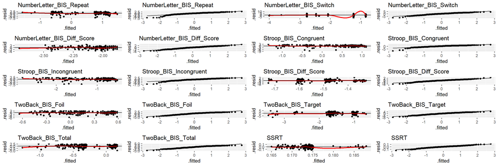

```r
# Create a list of those models used for the ANCOVA
get_models <- function(results_list){
  models_list <- setNames(
  lapply(names(results_list), function(name) results_list[[name]]$model),
  names(results_list)
 )
  return(models_list)
}

test_assumptions_of_MLR <- function(list_models){
  # list_models = named List of models
  plot_list <- list()
  for (dep_var in names(list_models)) {
    model <- list_models[[dep_var]]
    #par(mfrow = c(2, 2))
    # Residuals plot
    resid_plot <- ggplot(model, aes(x = .fitted, y = .resid)) +
      geom_point() +
      geom_smooth(se = FALSE, method = "loess", color = "red")+
      geom_hline(yintercept = 0) +
      labs(title= dep_var)
    qq_plot <- ggplot(model, aes(sample = .resid)) +
      stat_qq() +
      stat_qq_line() +
      labs(title= dep_var, x = ".fitted", y = ".resid")
    plot_list <- c(plot_list, list(resid_plot, qq_plot))
  }
  gridExtra::grid.arrange(grobs = plot_list,ncol = 4)
}

models_list <- get_models(results_uncorrected)
test_assumptions_of_MLR(models_list)
```

### Check GLM-Assumptions - statistical assessment

#### Test for Normality

```r
# Shapiro-Wilk for normality
shapiro_results <- apply(Patients_vs_HC_imp_conf_final[,performance_tasks], 2, FUN = shapiro.test)

shapiro_table <- data.frame(
  Statistic = sapply(shapiro_results, function(x) x$statistic),
  P_Value = sapply(shapiro_results, function(x) x$p.value)
)
row.names(shapiro_table) <- gsub("\\.W$", "", row.names(shapiro_table))
shapiro_table
```

|  | Statistic | P_Value |
| --- | --- | --- |
| NumberLetter_BIS_Repeat | 0.8373147 | 8.133203e-13 |
| NumberLetter_BIS_Switch | 0.9400730 | 8.808579e-07 |
| NumberLetter_BIS_Diff_Score | 0.9816130 | 1.891650e-02 |
| Stroop_BIS_Congruent | 0.7973618 | 2.139889e-14 |
| Stroop_BIS_Incongruent | 0.8461989 | 2.232142e-12 |
| Stroop_BIS_Diff_Score | 0.9581074 | 3.943130e-05 |
| TwoBack_BIS_Foil | 0.9407704 | 1.289537e-06 |
| TwoBack_BIS_Target | 0.9490013 | 6.504420e-06 |
| TwoBack_BIS_Total | 0.9558646 | 2.791852e-05 |
| SSRT | 0.9800545 | 1.379129e-02 |

For all executive functioning measures, the normality assumption is statistically violated.

#### Test for Homoscedasticity

Breusch-Pagan Test in Koenker-version (more robust if normality is violated)

```r
conduct_BPtest_multcols<- function(models_list){
  results_df <- do.call(rbind, lapply(names(models_list), function(model_name) {
  test_result <- bptest(models_list[[model_name]], studentize = TRUE)
  c(name = model_name, BP = round(test_result$statistic,2),
    df = test_result$parameter,
    p_value = round(test_result$p.value,3))
  }))

# Convert to a dataframe
results_df <- as.data.frame(results_df, stringsAsFactors = FALSE)
return(results_df)
}
conduct_BPtest_multcols(models_list)
```

| name | BP.BP | df.df | p_value.BP |
| --- | --- | --- | --- |
| NumberLetter_BIS_Repeat | 12.33 | 4 | 0.015 |
| NumberLetter_BIS_Switch | 5.87 | 4 | 0.209 |
| NumberLetter_BIS_Diff_Score | 8.14 | 4 | 0.086 |
| Stroop_BIS_Congruent | 14.89 | 4 | 0.005 |
| Stroop_BIS_Incongruent | 16.28 | 4 | 0.003 |
| Stroop_BIS_Diff_Score | 3.84 | 4 | 0.428 |
| TwoBack_BIS_Foil | 1.97 | 4 | 0.742 |
| TwoBack_BIS_Target | 15.6 | 4 | 0.004 |
| TwoBack_BIS_Total | 4.38 | 4 | 0.356 |
| SSRT | 3.18 | 4 | 0.528 |

For around half of the tests, the homoscedasticity is violated.

### Summarize assumption violations

These tasks were defined based on the visual and statistical check of assumptions. We focused on the visual assessment, as the Breusch-Pagan test is known to be biased in non-normally distributed data as used here.

```r
tasks_homosced_violated <- c("NumberLetter_BIS_Repeat", # visual and statistical violation of homogeneity
                       "NumberLetter_BIS_Switch", # visual violation of homogeneity
                       "Stroop_BIS_Diff_Score", # visual violation of homogeneity
                       "TwoBack_BIS_Target", # visual and statistical violation of homogeneity
                       "SSRT" #visual violation of homogeneity
                       )
```

## 2. Testing ANCOVA-specific assumptions

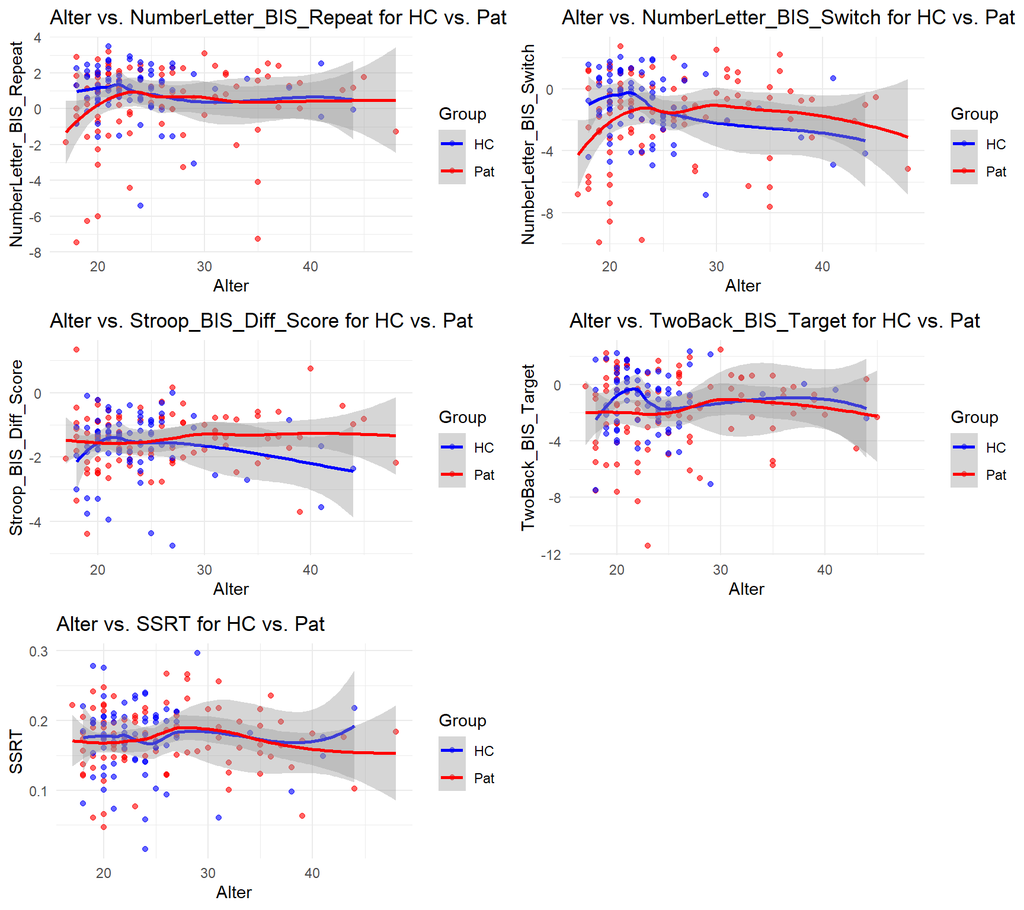

```r
# Loop through each task performance variable and plot Task Performance ~ Covariate per group (HC vs. Pat)
plot_linearity_pergroup <- function(data, covariate, performance_tasks){
   plot_list <- list()
  for (task in performance_tasks) {
    # Create the scatterplot of Age vs. Task Performance with Lowess Fit Line by group
    p <- ggplot(data, aes(x = !!sym(covariate), y = !!sym(task), color = as.factor(Gruppe))) +
      geom_point(alpha = 0.6) +  # Scatterplot points
      geom_smooth(method = "loess", se = TRUE) +  # Lowess Fit Line per group
      labs(title = paste(covariate, "vs.", task, "for HC vs. Pat"),
           x = covariate,
           y = task,
           color = "Group") +  # Correct label for legend
      scale_color_manual(values = c("blue", "red"), labels = c("HC", "Pat")) +  # Define colors and labels for groups
      theme_minimal()
    plot_list <- c(plot_list, list(p))
  }
  gridExtra::grid.arrange(grobs = plot_list,ncol = 2)
}

plot_linearity_pergroup(data = Patients_vs_HC_imp_conf_final, covariate = "Alter", performance_tasks = tasks_homosced_violated)
```

### Test for Group-Covariate Interactions

Assumption: Adding a group-covariate interaction does not improve the model fit.

```r
# Function to add interaction term
data <- Patients_vs_HC_imp_conf_final
test_interaction <- function(data, performance_task, covariates, cov_interest){
  covariate_main_effects <- paste(covariates, collapse = " + ")
  covariate_int_effect <- paste0("Gruppe:", cov_interest)
  formula_int <- paste(task, "~ Gruppe +", covariate_main_effects, "+", covariate_int_effect)
  full <- lm(formula_int,data)

  # Get variance analysis and test for significant contribution to variance explanation for each predictor/covariate
  #options(contrasts = c("contr.sum"))
  anova_results_sign <- car::Anova(full, type = 3, white = FALSE)
  p_value <- round(anova_results_sign[covariate_int_effect, "Pr(>F)"],3)
  return(p_value)
}

# Initialize a dataframe to store results, with an extra column for "Violated" or "Not Violated"
interaction_results <- data.frame(Task = tasks_homosced_violated,
                                  Interaction_Group_Sex_p_value = numeric(length(tasks_homosced_violated)),
                                  Interaction_Group_Education_p_value = numeric(length(tasks_homosced_violated)),
                                  Interaction_Group_Age_p_value = numeric(length(tasks_homosced_violated)),
                                  Interaction_Violated = character(length(tasks_homosced_violated)),  # New column
                                  stringsAsFactors = FALSE)

# Loop through each task and perform the interaction tests
for (i in seq_along(tasks_homosced_violated)) {
  task <- tasks_homosced_violated[i]
  # 1. Sex
  interaction_results$Interaction_Group_Sex_p_value[i] <- test_interaction(data = data, performance_task = task, covariates = covariates, cov_interest = "Geschlecht")
  # 2. Age
  interaction_results$Interaction_Group_Age_p_value[i] <- test_interaction(data = data, performance_task = task, covariates = covariates, cov_interest = "Alter")
  # 3. Education
  interaction_results$Interaction_Group_Education_p_value[i] <- test_interaction(data = data, performance_task = task, covariates = covariates, cov_interest = "Abschluss_Gymnasium")

  # Check if any of the p-values are less than 0.05
  if (interaction_results$Interaction_Group_Sex_p_value[i] < 0.05 ||
      interaction_results$Interaction_Group_Education_p_value[i] < 0.05 ||
      interaction_results$Interaction_Group_Age_p_value[i] < 0.05) {
    interaction_results$Interaction_Violated[i] <- "Violated"
  } else {
    interaction_results$Interaction_Violated[i] <- "Not Violated"
  }
}

# Output the table to review the results
pander(interaction_results, style = "rmarkdown", split.table = Inf, fontsize = "tiny")
```

| Task | Interaction_Group_Sex_p_value | Interaction_Group_Education_p_value | Interaction_Group_Age_p_value | Interaction_Violated |
| --- | --- | --- | --- | --- |
| NumberLetter_BIS_Repeat | 0.401 | 0.164 | 0.379 | Not Violated |
| NumberLetter_BIS_Switch | 0.42 | 0.164 | 0.017 | Violated |
| Stroop_BIS_Diff_Score | 0.873 | 0.622 | 0.11 | Not Violated |
| TwoBack_BIS_Target | 0.02 | 0.475 | 0.649 | Violated |
| SSRT | 0.111 | 0.798 | 0.836 | Not Violated |

```r
# Define models
tasks_homosced_correct_interaction <- interaction_results[interaction_results$Interaction_Group_Sex_p_value
< 0.05 | interaction_results$Interaction_Group_Education_p_value < 0.05 | interaction_results$Interaction_Group_Age_p_value < 0.05, "Task"]
tasks_homosced_violated_correct_homosced <- setdiff(tasks_homosced_violated, tasks_homosced_correct_interaction)
```

For some executive functioning measures, adding a group-covariate interaction improves the model fit. Models including such an interaction term are rerun in the next code section.

## 3 Model adjustments for violations

### 3.1 Rerun models with interaction terms (if necessary)

Run corrected ANCOVA models for tasks where group × covariate interaction improves model fit and check GLM assumptions again for corrected models.

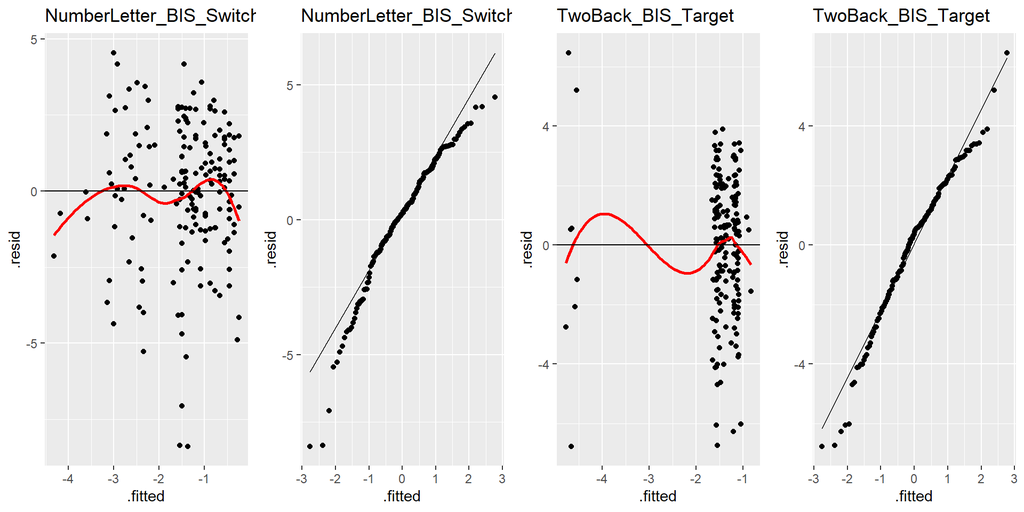

```r
run_corrected_interaction <- function(data, tasks_interaction, interaction_results, heterosced = FALSE){
  results_corrected_interaction <- list()
  for (task in tasks_interaction) {
    task_row <- which(interaction_results$Task == task)

    # Get the column names for the interaction p-values
    colnames_interaction <- colnames(interaction_results)[2:4]  # Interaction p-values columns
    # Find which column has a p-value < 0.05
    p_value_column <- which(interaction_results[task_row, 2:4] < 0.05)

    # Assign corresponding covariate interaction term based on column
    if (colnames_interaction[p_value_column] == "Interaction_Group_Sex_p_value") {
      covariate_int_effect <- "Gruppe:Geschlecht"  # Interaction with Sex
    } else if (colnames_interaction[p_value_column] == "Interaction_Group_Education_p_value") {
      covariate_int_effect <- "Gruppe:Abschluss_Gymnasium"  # Interaction with Education
    } else if (colnames_interaction[p_value_column] == "Interaction_Group_Age_p_value") {
      covariate_int_effect <- "Gruppe:Alter"  # Interaction with Age
    }

    # Define the main effects
    formula_interaction_switch <- paste(task, "~ Gruppe +", covariate_main_effects, "+", covariate_int_effect)

    # Run ANCOVA
    results_corrected_interaction[[task]] <- run_ancova(data = data, formula = formula_interaction_switch, heterosced = heterosced)
  }
  return(results_corrected_interaction)
}
results_corrected_interaction <- run_corrected_interaction(data = Patients_vs_HC_imp_conf_final,
                                                           tasks_interaction = tasks_homosced_correct_interaction,
                                                           interaction_results = interaction_results)

list_models_corrected_interaction <- get_models(results_corrected_interaction)
test_assumptions_of_MLR(list_models_corrected_interaction)
```

The visualizations shows that homoscedasticity is not violated anymore in Number_Letter_BIS_Switch but remains violated in TwoBack_BIS_Target. Therefore, TwoBack_BIS_Target is corrected for heteroscedasticity as well in 3.3.

### 3.2 Rerun models with correction for heteroscedasticity

```r
results_corrected_homogeneity <- list()
for (task in tasks_homosced_violated_correct_homosced) {
  formula_ancova <- paste(task, "~ Gruppe +", covariate_main_effects)
  results_corrected_homogeneity[[task]] <- run_ancova(data = Patients_vs_HC_imp_conf_final,formula = formula_ancova, heterosced = TRUE)
}
```

### 3.3. Rerun Models with both interaction and heteroscedasticity correction

```r
tasks_homosced_violated_correct_homosced_interaction <- c("TwoBack_BIS_Target")
results_corrected_both <- run_corrected_interaction(data = Patients_vs_HC_imp_conf_final, tasks = tasks_homosced_violated_correct_homosced_interaction,
                          interaction_results = interaction_results,
                          heterosced = TRUE)
```

```
## Coefficient covariances computed by hccm()
```

```
## NOTE: Results may be misleading due to involvement in interactions
```

## 5. Summarize

### Collect results

```r
combined_results <- results_uncorrected

for (task in names(results_corrected_interaction)) {
    combined_results[[task]] <- results_corrected_interaction[[task]]
}
for (task in names(results_corrected_homogeneity)) {
    combined_results[[task]] <- results_corrected_homogeneity[[task]]
}
for (task in names(results_corrected_both)) {
    combined_results[[task]] <- results_corrected_both[[task]]
}

# Combine results to a table
table_summary <- summarize_ancova_results(results_list = combined_results)
```

### Correct results for multiple comparisons

```r
# Apply correction for multiple comparisons
table_summary$p_values_adjusted <- p.adjust(table_summary$p_value, method = "BH")
table_summary$F_value <- round(table_summary$F_value,2)
table_summary$error_reduction_due_to_predictor <- round(table_summary$error_reduction_due_to_predictor,2)
table_summary$p_value <- round(table_summary$p_value,3)

table_summary
```

| Name | error_reduction_due_to_predictor | df | F_value | p_value | partial_omega_squared | correction_for | p_values_adjusted |
| --- | --- | --- | --- | --- | --- | --- | --- |
| NumberLetter_BIS_Repeat | NA | 1, 173 | 1.07 | 0.303 | 0.000 | correction for heteroscedasticity | 0.50448824 |
| NumberLetter_BIS_Switch | 36.77 | 1, 172 | 6.79 | 0.010 | 0.031 | interaction term Group:Age added | 0.09994514 |
| NumberLetter_BIS_Diff_Score | 0.40 | 1, 173 | 0.24 | 0.625 | -0.004 | no correction | 0.69486240 |
| Stroop_BIS_Congruent | 2.97 | 1, 172 | 1.08 | 0.300 | 0.000 | no correction | 0.50448824 |
| Stroop_BIS_Incongruent | 1.02 | 1, 172 | 0.39 | 0.534 | -0.003 | no correction | 0.66753899 |
| Stroop_BIS_Diff_Score | NA | 1, 172 | 0.57 | 0.452 | -0.002 | correction for heteroscedasticity | 0.64505196 |
| TwoBack_BIS_Foil | 5.86 | 1, 169 | 2.29 | 0.132 | 0.007 | no correction | 0.33003042 |
| TwoBack_BIS_Target | NA | 1, 168 | 3.48 | 0.064 | 0.014 | interaction term Group:Sex added, correction for heteroscedasticity | 0.27309179 |
| TwoBack_BIS_Total | 7.89 | 1, 169 | 3.06 | 0.082 | 0.011 | no correction | 0.27309179 |
| SSRT | NA | 1, 168 | 0.01 | 0.937 | -0.006 | correction for heteroscedasticity | 0.93745720 |

### Make nice table

```r
# Change taks names and column names
rename_map <- c(
  'NumberLetter_BIS_Repeat' = "Number-Letter: Repeat",
  'NumberLetter_BIS_Switch' = "Number-Letter: Switch",
  'NumberLetter_BIS_Diff_Score' = "Number-Letter: Switch - Repeat",
  'Stroop_BIS_Congruent' = "Stroop: Congruent",
  'Stroop_BIS_Incongruent' = "Stroop: Incongruent",
  'Stroop_BIS_Diff_Score' = "Stroop: Incongruent - Congruent",
  'TwoBack_BIS_Foil' = "2-Back: Foil",
  'TwoBack_BIS_Target' = "2-Back: Target",
  'TwoBack_BIS_Total' = "2-Back: Total",
  'SSRT' = "Stop-Signal RT")
table_summary <- table_summary %>%mutate(Name = dplyr::recode(Name, !!!rename_map))
#table_summary$Name <- recode(table_summary$Name, !!!rename_map)

colnames(table_summary) <- dplyr::recode(colnames(table_summary),"Name" = "Performance Measure",
                                  "error_reduction_due_to_predictor" = "Type III SSq explained by Group",
                                  "F_value" = "F-Value",
                                  "p_value" = "p-Value",
                                  "partial_omega_squared" = "Partial Omega Squared",
                                  "correction_for" = "Corrections",
                                  "p_values_adjusted" = "adj. p-Value")

ft_t_test <- flextable::flextable(table_summary)

format_flextable_portrait <- flextable_settings(word_orientation = "portrait")

# Set table properties
ft_t_test <- set_table_properties(ft_t_test, width = 1, layout = "autofit")
# Round
ft_t_test  <- colformat_double(ft_t_test , digits = 2)

# Header in bold
ft_t_test <- bold(ft_t_test, bold = TRUE, part = "header")

# Alignments
ft_t_test <- align(ft_t_test, j = 1, align = "left", part = "all") # first column
ft_t_test <- align(ft_t_test, j = 2:ncol(table_summary), align = "center", part = "all") # rest


save_as_docx(
  ft_t_test,
  path = file.path(results_path,"ANCOVA.docx"),
  pr_section = format_flextable_portrait)
ft_t_test
```

| Performance Measure | Type III SSq explained by Group | df | F-Value | p-Value | Partial Omega Squared | Corrections | adj. p-Value |
| --- | --- | --- | --- | --- | --- | --- | --- |
| Number-Letter: Repeat |  | 1, 173 | 1.07 | 0.30 | 0.00 | correction for heteroscedasticity | 0.50 |
| Number-Letter: Switch | 36.77 | 1, 172 | 6.79 | 0.01 | 0.03 | interaction term Group:Age added | 0.10 |
| Number-Letter: Switch - Repeat | 0.40 | 1, 173 | 0.24 | 0.62 | -0.00 | no correction | 0.69 |
| Stroop: Congruent | 2.97 | 1, 172 | 1.08 | 0.30 | 0.00 | no correction | 0.50 |
| Stroop: Incongruent | 1.02 | 1, 172 | 0.39 | 0.53 | -0.00 | no correction | 0.67 |
| Stroop: Incongruent - Congruent |  | 1, 172 | 0.57 | 0.45 | -0.00 | correction for heteroscedasticity | 0.65 |
| 2-Back: Foil | 5.86 | 1, 169 | 2.29 | 0.13 | 0.01 | no correction | 0.33 |
| 2-Back: Target |  | 1, 168 | 3.48 | 0.06 | 0.01 | interaction term Group:Sex added, correction for heteroscedasticity | 0.27 |
| 2-Back: Total | 7.89 | 1, 169 | 3.06 | 0.08 | 0.01 | no correction | 0.27 |
| Stop-Signal RT |  | 1, 168 | 0.01 | 0.94 | -0.01 | correction for heteroscedasticity | 0.94 |